# Manual Model Development - Lab

```r
?car
```

```
No documentation for ‘car’ in specified packages and libraries:
you could try ‘??car’
```

```r
prestige <- Prestige
```

|  | education | income | women | prestige | type |
| --- | --- | --- | --- | --- | --- |
| gov.administrators | 13.11 | 12351 | 11.16 | 68.8 | prof |
| general.managers | 12.26 | 25879 | 4.02 | 69.1 | prof |
| accountants | 12.77 | 9271 | 15.70 | 63.4 | prof |
| purchasing.officers | 11.42 | 8865 | 9.11 | 56.8 | prof |
| chemists | 14.62 | 8403 | 11.68 | 73.5 | prof |
| physicists | 15.64 | 11030 | 5.13 | 77.6 | prof |
| biologists | 15.09 | 8258 | 25.65 | 72.6 | prof |
| architects | 15.44 | 14163 | 2.69 | 78.1 | prof |
| civil.engineers | 14.52 | 11377 | 1.03 | 73.1 | prof |
| mining.engineers | 14.64 | 11023 | 0.94 | 68.8 | prof |

[output cut: 88 more lines]

```r
prestige_trim <- prestige %>%
    drop_na() %>%
    select(-census)
```

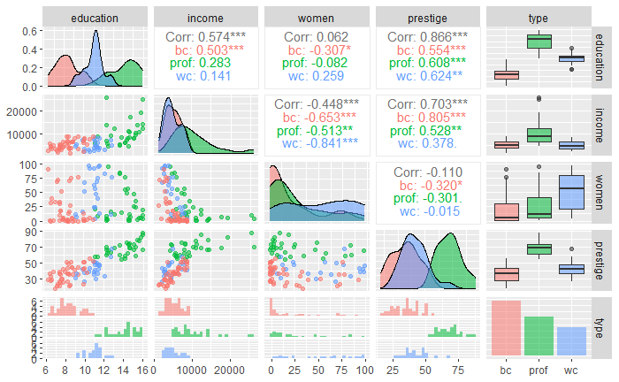

High correlation, high significance with Education. High correlation, high significance with Income low negative correlation with women, not marked as significant there seems to be a visible correlation between type and prestige: bc almost exclusively bottom half, prof top, wc sort of middle but skews bottom

```r
mod1a <- lm(prestige ~ education,
            data = prestige_trim)

summary(mod1a)
```

```
Call:
lm(formula = prestige ~ education, data = prestige_trim)

Residuals:
    Min      1Q  Median      3Q     Max
-21.605  -6.151   0.366   6.565  17.540

Coefficients:
            Estimate Std. Error t value Pr(>|t|)
(Intercept) -10.8409     3.5285  -3.072  0.00276 **
education     5.3884     0.3168  17.006  < 2e-16 ***
---
Signif. codes:  0 ‘***’ 0.001 ‘**’ 0.01 ‘*’ 0.05 ‘.’ 0.1 ‘ ’ 1

Residual standard error: 8.578 on 96 degrees of freedom
Multiple R-squared:  0.7508,    Adjusted R-squared:  0.7482
F-statistic: 289.2 on 1 and 96 DF,  p-value: < 2.2e-16
```

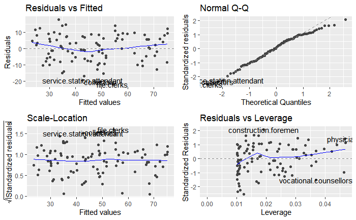

```r
autoplot(mod1a)
```

```r
mod1b <- lm(prestige ~ type,
            data = prestige_trim)

summary(mod1b)
```

```
Call:
lm(formula = prestige ~ type, data = prestige_trim)

Residuals:
     Min       1Q   Median       3Q      Max
-18.2273  -7.1773  -0.0854   6.1174  25.2565

Coefficients:
            Estimate Std. Error t value Pr(>|t|)
(Intercept)   35.527      1.432  24.810  < 2e-16 ***
typeprof      32.321      2.227  14.511  < 2e-16 ***
typewc         6.716      2.444   2.748  0.00718 **
---
Signif. codes:  0 ‘***’ 0.001 ‘**’ 0.01 ‘*’ 0.05 ‘.’ 0.1 ‘ ’ 1

Residual standard error: 9.499 on 95 degrees of freedom
Multiple R-squared:  0.6976,    Adjusted R-squared:  0.6913
F-statistic: 109.6 on 2 and 95 DF,  p-value: < 2.2e-16
```

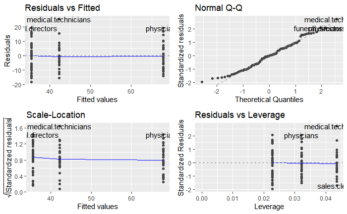

```r
autoplot(mod1b)
```

prestige ~ education (mod1a): r² = 0.7508 std error = 8.578 predictor is statistically significant: p < 0.001

paired plots mostly ok, bit of a u-shape in RvF

prestige ~ type (mod1b): r² = 0.6976 std error = 9.499 predictor is statistically significant across all levels: - p < 0.001 p < 0.001 p < 0.01

paired plots mostly ok, Q-Q maybe a little erratic towards the top?

education is a larger contributor, so makes more sense as the place to start.

model:

prestige = b0 + b1 * education prestige = -10.8409 + 5.3884 * education

jobs start at negative prestige, but score increases by 5.38 per year of education

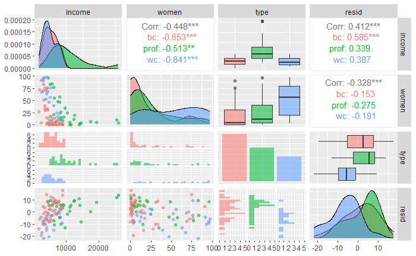

significant strong positive correlation between residuals and income significant strong negative correlation between women and income

```r
mod2a <- lm(prestige ~ education + income,
            data = prestige_trim)

summary(mod2a)
```

```
Call:
lm(formula = prestige ~ education + income, data = prestige_trim)

Residuals:
     Min       1Q   Median       3Q      Max
-16.9367  -4.8881   0.0116   4.9690  15.9280

Coefficients:
              Estimate Std. Error t value Pr(>|t|)
(Intercept) -7.6210352  3.1162309  -2.446   0.0163 *
education    4.2921076  0.3360645  12.772  < 2e-16 ***
income       0.0012415  0.0002185   5.682 1.45e-07 ***
---
Signif. codes:  0 ‘***’ 0.001 ‘**’ 0.01 ‘*’ 0.05 ‘.’ 0.1 ‘ ’ 1

Residual standard error: 7.45 on 95 degrees of freedom
Multiple R-squared:  0.814, Adjusted R-squared:  0.8101
F-statistic: 207.9 on 2 and 95 DF,  p-value: < 2.2e-16
```

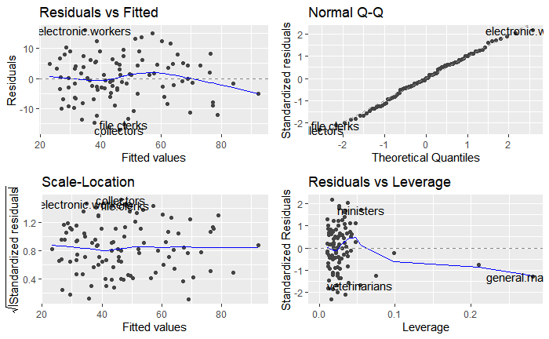

```r
autoplot(mod2a)
```

```r
mod2b <- lm(prestige ~ education + type,
            data = prestige_trim)

summary(mod2b)
```

```
Call:
lm(formula = prestige ~ education + type, data = prestige_trim)

Residuals:
    Min      1Q  Median      3Q     Max
-19.410  -5.508   1.360   5.694  17.171

Coefficients:
            Estimate Std. Error t value Pr(>|t|)
(Intercept)  -2.6982     5.7361  -0.470   0.6392
education     4.5728     0.6716   6.809 9.16e-10 ***
typeprof      6.1424     4.2590   1.442   0.1526
typewc       -5.4585     2.6907  -2.029   0.0453 *
---
Signif. codes:  0 ‘***’ 0.001 ‘**’ 0.01 ‘*’ 0.05 ‘.’ 0.1 ‘ ’ 1

Residual standard error: 7.814 on 94 degrees of freedom
Multiple R-squared:  0.7975,    Adjusted R-squared:  0.791
F-statistic: 123.4 on 3 and 94 DF,  p-value: < 2.2e-16
```

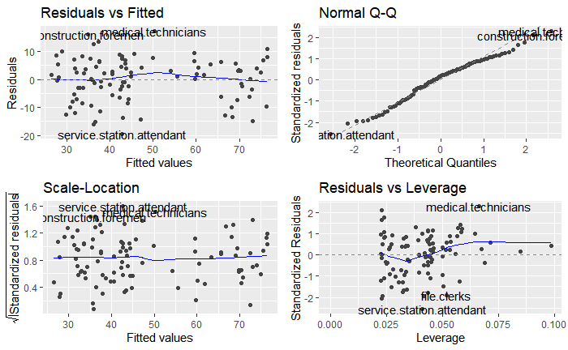

```r
autoplot(mod2b)
```

again type is competitive, but not as much as its rival.

prestige ~ education + income (mod2a): r² = 0.814 std error = 7.45  
predictors are statistically significant: p < 0.001 for both

paired plots mostly ok, bit of a negative trend in the second half of RvF

prestige ~ education + type (mod1b): r² = 0.7975 std error = 7.814  
predictors have issues in significance: education remains p < 0.001, but the only significant level of job type is now wc

paired plots mostly ok, little hump in RvF

income by far a better addition to the model.

model formula:

prestige = b0 + (b1 * education) + (b2 * income) prestige = -7.621 + (4.292 * education) + (0.001 * income)

base prestige of -7.6, increases by 4.292 per year of education and by 0.001 per dollar of income

|  | women | type | resid |
| --- | --- | --- | --- |
| gov.administrators | 11.16 | prof | 4.8172831 |
| general.managers | 4.02 | prof | -8.0299358 |
| accountants | 15.70 | prof | 4.7005332 |
| purchasing.officers | 9.11 | prof | 4.3989424 |
| chemists | 11.68 | prof | 7.9377881 |
| physicists | 5.13 | prof | 4.3983211 |
| biologists | 25.65 | prof | 5.2005204 |
| architects | 2.69 | prof | 1.8670077 |
| civil.engineers | 1.03 | prof | 4.2746683 |
| mining.engineers | 0.94 | prof | -0.1008806 |

[output cut: 88 more lines]

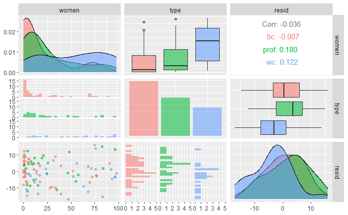

small negative correlation between women and the remaining residuals

```r
mod3a <- lm(prestige ~ education + income + women,
            data = prestige_trim)

summary(mod3a)
```

```
Call:
lm(formula = prestige ~ education + income + women, data = prestige_trim)

Residuals:
     Min       1Q   Median       3Q      Max
-16.8834  -4.3572  -0.2191   4.9286  16.4533

Coefficients:
              Estimate Std. Error t value Pr(>|t|)
(Intercept) -7.5242222  3.1377519  -2.398   0.0185 *
education    4.3624246  0.3749725  11.634  < 2e-16 ***
income       0.0011723  0.0002721   4.308 4.05e-05 ***
women       -0.0129461  0.0300771  -0.430   0.6679
---
Signif. codes:  0 ‘***’ 0.001 ‘**’ 0.01 ‘*’ 0.05 ‘.’ 0.1 ‘ ’ 1

Residual standard error: 7.482 on 94 degrees of freedom
Multiple R-squared:  0.8144,    Adjusted R-squared:  0.8084
F-statistic: 137.5 on 3 and 94 DF,  p-value: < 2.2e-16
```

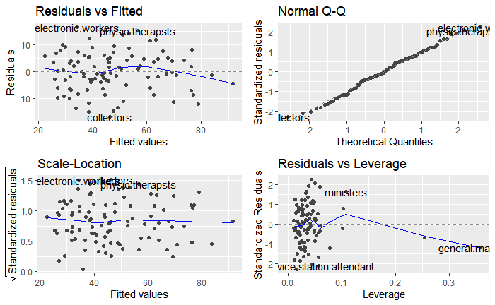

```r
autoplot(mod3a)
```

```r
mod3b <- lm(prestige ~ education + income + type,
            data = prestige_trim)

summary(mod3b)
```

```
Call:
lm(formula = prestige ~ education + income + type, data = prestige_trim)

Residuals:
     Min       1Q   Median       3Q      Max
-14.9529  -4.4486   0.1678   5.0566  18.6320

Coefficients:
              Estimate Std. Error t value Pr(>|t|)
(Intercept) -0.6229292  5.2275255  -0.119    0.905
education    3.6731661  0.6405016   5.735 1.21e-07 ***
income       0.0010132  0.0002209   4.586 1.40e-05 ***
typeprof     6.0389707  3.8668551   1.562    0.122
typewc      -2.7372307  2.5139324  -1.089    0.279
---
Signif. codes:  0 ‘***’ 0.001 ‘**’ 0.01 ‘*’ 0.05 ‘.’ 0.1 ‘ ’ 1

Residual standard error: 7.095 on 93 degrees of freedom
Multiple R-squared:  0.8349,    Adjusted R-squared:  0.8278
F-statistic: 117.5 on 4 and 93 DF,  p-value: < 2.2e-16
```

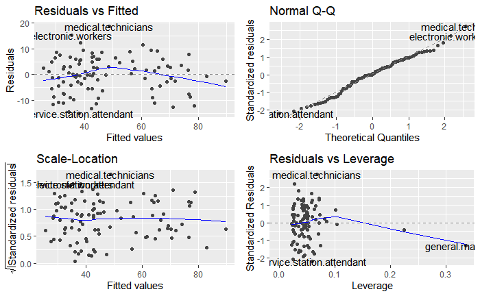

```r
autoplot(mod3b)
```

Type might actually win!

prestige ~ education + income + women (mod3a): r² = 0.8144 (effectively no change) std error = 7.482  
women is not a statistically significant addition to the predictors (p = 0.6679)

paired plots mostly ok, bit of a wiggle in RvF

prestige ~ education + income + type (mod3b): r² = 0.8349 (+0.02) std error = 7.095  
predictors have issues in significance: now of the individual levels are significant, in fact bc (intercept) is p > 0.9!

paired plots mostly ok, bit of a curve in RvF

```r
summary(mod3b)
```

```
Call:
lm(formula = prestige ~ education + income + type, data = prestige_trim)

Residuals:
     Min       1Q   Median       3Q      Max
-14.9529  -4.4486   0.1678   5.0566  18.6320

Coefficients:
              Estimate Std. Error t value Pr(>|t|)
(Intercept) -0.6229292  5.2275255  -0.119    0.905
education    3.6731661  0.6405016   5.735 1.21e-07 ***
income       0.0010132  0.0002209   4.586 1.40e-05 ***
typeprof     6.0389707  3.8668551   1.562    0.122
typewc      -2.7372307  2.5139324  -1.089    0.279
---
Signif. codes:  0 ‘***’ 0.001 ‘**’ 0.01 ‘*’ 0.05 ‘.’ 0.1 ‘ ’ 1

Residual standard error: 7.095 on 93 degrees of freedom
Multiple R-squared:  0.8349,    Adjusted R-squared:  0.8278
F-statistic: 117.5 on 4 and 93 DF,  p-value: < 2.2e-16
```

New model formula:

bc is the reference class, which is now the intercept (b0)

prestige = -0.6229292 + (3.6731661 * education) + (0.0010132 * income) + (6.0389707 * (type == prof)) + (-2.7372307 * (type == wc))

|  | education | income | women | type | resid |
| --- | --- | --- | --- | --- | --- |
| gov.administrators | 13.11 | 12351 | 11.16 | prof | 2.714803027 |
| general.managers | 12.26 | 25879 | 4.02 | prof | -7.569482709 |
| accountants | 12.77 | 9271 | 15.70 | prof | 1.684314374 |
| purchasing.officers | 11.42 | 8865 | 9.11 | prof | 0.454444961 |
| chemists | 14.62 | 8403 | 11.68 | prof | 5.868408829 |
| physicists | 15.64 | 11030 | 5.13 | prof | 3.560121061 |
| biologists | 15.09 | 8258 | 25.65 | prof | 3.388933790 |
| architects | 15.44 | 14163 | 2.69 | prof | 1.620420145 |
| civil.engineers | 14.52 | 11377 | 1.03 | prof | 2.822489018 |
| mining.engineers | 14.64 | 11023 | 0.94 | prof | -1.559620535 |

[output cut: 88 more lines]

```r
coplot("education":"income", data = prestige_resid)
```

[output not shown]